# PS04 pre-lecture: importing data and tidy data

## Importing data & tidy data

with the **readr** and **tidyr** packages

reshaping a data frame `wide <-> long`

- `read_csv()`
- `pivot_longer()`
- `pivot_wider()`

Every tool from the last two chapters assumes your data is tidy.

## Tidy data

Three Rules

- Each **variable** is its own column.
- Each **observation** is its own row.
- Each **value** is its own cell.
- Untidy data is not wrong, it is just not ready yet.

## read_csv()

Import a Spreadsheet

read_csv() is not read.csv(): the underscore version is the tidyverse one.

## read_csv()

Example

what to call the result

```r
dem_score <- read_csv("https://moderndive.com/data/dem_score.csv")
```

the verb (function) where the file is: a path or a URL

## wide format

Values Hidden In Headers

## pivot_longer()

Wide To Long

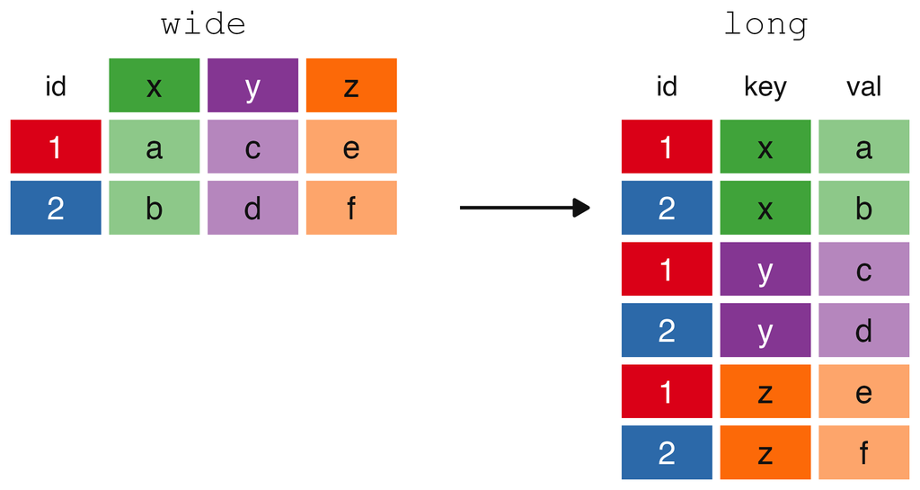

## pivot_longer()

Example

the data frame

```r
drinks_smaller_tidy <- drinks_smaller |>
  pivot_longer(names_to = "type", values_to = "servings", cols = -country)
```

the verb (function) new column for the old headers new column for the values which columns to reshape

## pivot_wider()

Long To Wide

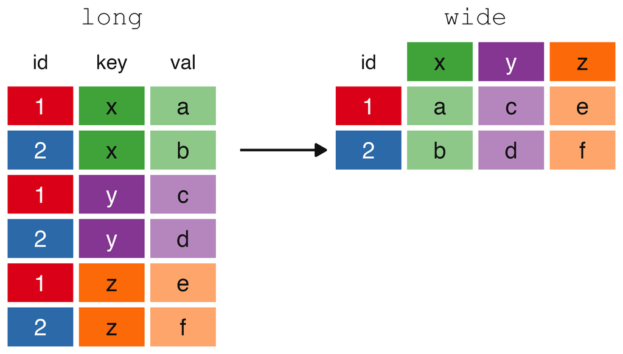

## pivot_wider()

Example

```r
drinks_smaller_tidy |>
  pivot_wider(names_from = type, values_from = servings)
```

the verb (function) column supplying the new headers column supplying the new values

## tidyverse

The Umbrella Package

- **library(tidyverse)** loads ggplot2, dplyr, readr, tidyr and more.
- **readr** imports. **tidyr** reshapes.
- **dplyr** wrangles. **ggplot2** plots.
- They share a design, so what you learn on one transfers to the rest.